# Mapping Antimicrobial Resistance Across U.S. States

An Introduction to GIS Methods for Environmental Pharmacoepidemiology

ISPE 2026 Pre-Conference Course

2026-08-27

# 1 Welcome

None of these files contain a shapefile, a latitude, or a longitude. That is deliberate. Most pharmacoepidemiology environmental exposure data you will encounter in practice — surveillance reports, claims data aggregated for privacy, vital statistics — arrives as **tables tied to an administrative area** (state, county, ZIP) **and to a time period** (month, year).

## 1.1 Learning objectives

By the end, you will be able to:

- Import and clean real, messy public-health surveillance data in R
- Obtain U.S. state boundary polygons and understand what a coordinate reference system (CRS) is doing for you
- Perform an **attribute join** — attaching non-spatial data to spatial geometry by a shared key — the single most common GIS operation you will do in this field
- Build choropleth (thematic) maps with `ggplot2` + `sf`
- Build **small-multiples map panels** to show how a distribution changes across years and across seasons, and understand why the color scale has to be shared across panels for the comparison to be fair
- Recognize **seasonality** in area-level surveillance data using both a simple distribution plot and a mapped version of the same pattern
- Name the specific ways area-level GIS analysis can mislead you in environmental pharmacoepidemiology (MAUP, ecological fallacy, surveillance effort bias) — and recognize them in your own results

# 2 Setup

```r
# Run once. Skip if already installed.
install.packages(c("sf", "tigris", "dplyr", "tidyr", "readr", "readxl",
                    "janitor", "ggplot2", "viridis", "scales"))
```

```r
library(sf)        # spatial vector data: geometry + attributes
library(tigris)     # download US Census boundary files
library(dplyr)       # data wrangling
library(tidyr)         # expand_grid(), for building complete state x time panels
library(readr)          # fast, sane CSV reading
library(readxl)           # read Excel sheets
library(janitor)           # clean up ugly column names
library(ggplot2)             # mapping and plotting
library(viridis)               # colorblind-safe palettes
library(scales)                  # nicer plot labels

options(tigris_use_cache = TRUE)   # cache downloaded shapefiles locally
sf::sf_use_s2(TRUE)                 # spherical geometry engine (default, just being explicit)
```

> **Teaching note:** `tigris` downloads boundary files from the U.S. Census Bureau the first time you use them, then caches them on disk. If you are offline, use the pre-downloaded `states_sf.rds` file and load it with `states_sf <- readRDS("states_sf.rds")` instead of running the `tigris::states()` call below.

# 3 Part 1 — Import and clean the tabular data

## 3.1 1a. Clinical outcome: MDR *E. coli* resistance by state

```r
ecoli_raw <- read_csv("../data/ARPSP_MDR-Ecoli---Percent-Resistant-in-2024.csv")

ecoli <- ecoli_raw %>%
  clean_names() %>%                 # tidies "Percent Resistant" -> percent_resistant
  select(state, percent_resistant) %>%
  mutate(percent_resistant = as.numeric(percent_resistant))

glimpse(ecoli)
```

```
## Rows: 52
## Columns: 2
## $ state             <chr> "Alaska", "Alabama", "Arkansas", "Arizona", "Califor…
## $ percent_resistant <dbl> 3.4, 8.3, 10.8, 8.8, 17.3, 9.0, 14.4, 19.7, 10.5, 11…
```

**Stop and look.** How many rows do you have? Is that one row per U.S. state? (Hint: `nrow(ecoli)`; check whether Puerto Rico and DC are included with `unique(ecoli$state)`.) Knowing your unit of observation *before* you map it is a GIS habit, as it will help you determine what your eventual polygon layer needs to contain.

## 3.2 1b. Environmental exposure signal: BEAM environmental isolates by state

The raw BEAM file is semicolon-delimited and has a European-style thousands separator in the `Year` column (e.g. `"2,024"`). This is completely typical of real surveillance exports.

```r
beam_raw <- read_delim("../data/BEAM_Dashboard_-_Report_Data_20260804.csv",
                        delim = ";", show_col_types = FALSE)

beam <- beam_raw %>%
  clean_names() %>%
  mutate(year = as.numeric(gsub(",", "", year)))

# Keep only environmental-source Salmonella isolates from 2024, as a
# first, simple look -- one state, one year, one map.
beam_env_2024 <- beam %>%
  filter(year == 2024, source_type == "Environment", pathogen == "Salmonella")

# The "state" column has some junk values in it (data-entry artifacts like
# "N/", "US", "OU"). A real GIS key needs to be *valid* before you can join
# on it -- always sanity-check your join key.
valid_state_codes <- c(state.abb, "DC")   # state.abb is a built-in R constant
sort(unique(beam_env_2024$state))
```

```
##  [1] "AZ" "CA" "FL" "GA" "HI" "IL" "IN" "MA" "MN" "NC" "NV" "NY" "OH" "PA" "TN"
## [16] "TX" "UT" "VA" "VT" "WA" "WI"
```

```r
beam_env_clean <- beam_env_2024 %>%
  filter(state %in% valid_state_codes) %>%
  group_by(state) %>%
  summarize(env_isolates = sum(number_of_isolates, na.rm = TRUE), .groups = "drop")

beam_env_clean
```

```
## # A tibble: 21 × 2
##    state env_isolates
##    <chr>        <dbl>
##  1 AZ               1
##  2 CA               8
##  3 FL              37
##  4 GA              14
##  5 HI               5
##  6 IL               1
##  7 IN               2
##  8 MA               4
##  9 MN              74
## 10 NC              17
## # ℹ 11 more rows
```

**Discussion:** Only about 20 states show up here at all, for 2024 alone. Is that because *Salmonella* genuinely isn’t present in the environment elsewhere — or because those states simply aren’t sampling environmental sources? Hold onto that question; we’ll come back to it, with more data behind us, in Parts 5-7. In environmental pharmacoepidemiology, an “exposure” layer built from surveillance data is never just measuring exposure — it’s also measuring *where people looked.*

**Sampling choices**

# 4 Part 2 — Get the map: state boundary polygons

```r
states_sf <- tigris::states(cb = TRUE, resolution = "20m", year = 2025)

states_sf <- states_sf %>%
  clean_names() %>%
  select(name, stusps, geoid, geometry)

glimpse(states_sf)
```

```
## Rows: 52
## Columns: 4
## $ name     <chr> "Minnesota", "Maryland", "Texas", "Georgia", "Virginia", "Ill…
## $ stusps   <chr> "MN", "MD", "TX", "GA", "VA", "IL", "WI", "FL", "IA", "MO", "…
## $ geoid    <chr> "27", "24", "48", "13", "51", "17", "55", "12", "19", "29", "…
## $ geometry <MULTIPOLYGON [°]> MULTIPOLYGON (((-97.22904 4..., MULTIPOLYGON (((…
```

`states_sf` is an `sf` object: an ordinary data frame with one extra column, `geometry`, holding the polygon boundary for each state. Everything you already know about `dplyr::filter()`, `mutate()`, and `left_join()` still works!!.

Offline fallback: if tigris::states() times out or you have no internet, download the cb_2025_us_state_20m folder next to this .Rmd (or adjust the path below), then use this instead of the tigris::states() call. states_sf <- sf::read_sf(“cb_2025_us_state_20m/cb_2025_us_state_20m.shp”)

`states_sf <- states_sf %>% clean_names() %>% select(name, stusps, geoid, geometry)`

`glimpse(states_sf)`

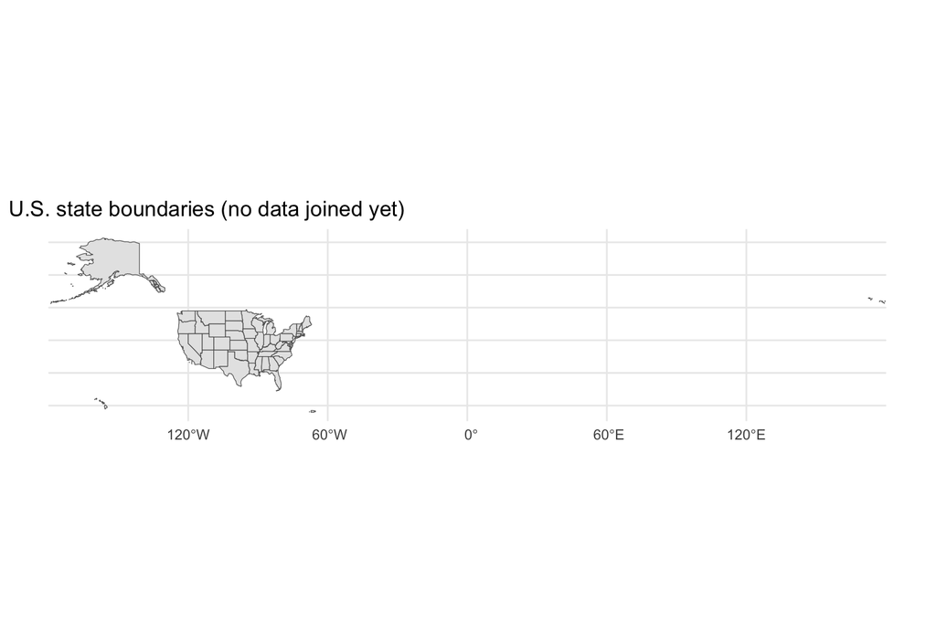

```r
ggplot(states_sf) +
  geom_sf() +
  theme_minimal() +
  labs(title = "U.S. state boundaries (no data joined yet)")
```

For the rest of this exercise we’ll restrict to the contiguous 48 states + DC. Alaska, Hawaii, Puerto Rico, and the outlying territories are real and important, but they sit far outside the CONUS bounding box and would either get cut off or force us to shrink every other state to fit them on the same simple map. (`tigris::shift_geometry()` can reposition them into inset boxes if you need a true all-50-states map later — worth knowing exists, out of scope for today.) For a first pass at small-multiples mapping, keeping the geography simple lets us focus on the actual skill: comparing panels to each other.

```r
conus_codes <- setdiff(c(state.abb, "DC"), c("AK", "HI"))

states_conus <- states_sf %>%
  filter(stusps %in% conus_codes) %>%
  st_transform(5070)   # Albers Equal Area Conic — standard projected CRS for CONUS
```

> **CRS check-in.** `tigris` gives you data in geographic coordinates (NAD83, unprojected — degrees of latitude/longitude). We just projected to EPSG:5070, an *equal-area* projection built for the contiguous U.S. Projection matters here for two concrete reasons: (1) `ggplot2` will draw a nicer, less distorted map, and (2) any analysis that depends on area or distance (which ours doesn’t today, but often will) requires a projected CRS to be correct. Always ask “what CRS is this in, and does that CRS make sense for what I’m about to compute?”

# 5 Part 3 — Attribute join

This is the step that turns a spreadsheet into a map. We attach our two non-spatial tables to `states_conus` by matching a shared key: full state name for the ARPSP data, two-letter abbreviation for the BEAM data.

```r
map_data <- states_conus %>%
  left_join(ecoli, by = c("name" = "state")) %>%
  left_join(beam_env_clean, by = c("stusps" = "state")) %>%
  mutate(env_isolates = coalesce(env_isolates, 0))  # no report = 0 isolates, not missing

summary(map_data$percent_resistant)
```

```
##    Min. 1st Qu.  Median    Mean 3rd Qu.    Max.    NA's
##   0.000   6.850   9.400   9.894  12.825  23.000       1
```

```r
summary(map_data$env_isolates)
```

```
##    Min. 1st Qu.  Median    Mean 3rd Qu.    Max.
##   0.000   0.000   0.000   6.735   4.000  98.000
```

**Stop and check your join.** A silent join failure — rows that should have matched but didn’t, because of a trailing space, a “St.” vs “Saint”, a different case — is the single most common source of a blank or wrong-looking choropleth map. Before you ever trust a joined map, run:

```r
map_data %>%
  st_drop_geometry() %>%
  filter(is.na(percent_resistant)) %>%
  select(name, stusps)
```

```
##      name stusps
## 1 Wyoming     WY
```

If that returns states you *expected* to have data, go back and find the mismatch. If it’s empty, your join key worked.

# 6 Part 4 — Your first choropleth maps

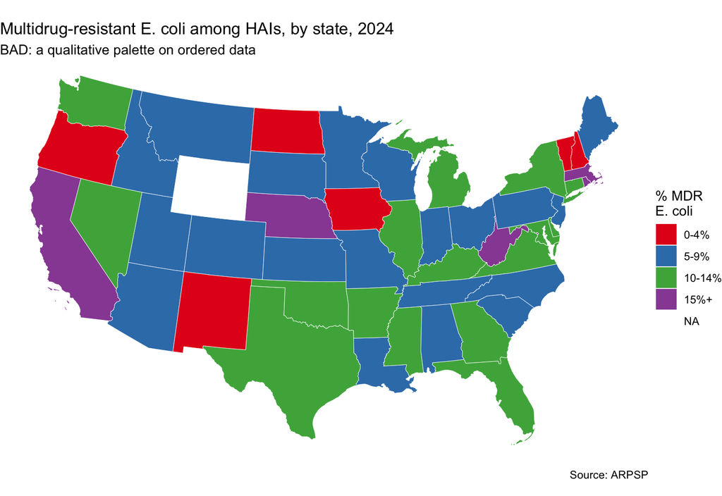

```r
# MAP 1 -- BAD: a qualitative (non-ordered) palette forced onto ordered data.
# Set1's colors have no natural low-to-high sequence -- red isn't obviously
# "more resistant" than blue or green, so the reader has to keep re-checking
# the legend instead of reading the map at a glance. Also rough for
# colorblind readers (red/green together).
map_data_bad <- map_data %>%
  mutate(resist_bin = cut(percent_resistant,
                           breaks = c(0, 5, 10, 15, 25),
                           labels = c("0-4%", "5-9%", "10-14%", "15%+"),
                           include.lowest = TRUE))

ggplot(map_data_bad) +
  geom_sf(aes(fill = resist_bin), color = "white", linewidth = 0.15) +
  scale_fill_brewer(palette = "Set1", name = "% MDR\nE. coli") +
  theme_void() +
  labs(title = "Multidrug-resistant E. coli among HAIs, by state, 2024",
       subtitle = "BAD: a qualitative palette on ordered data",
       caption = "Source: ARPSP")
```

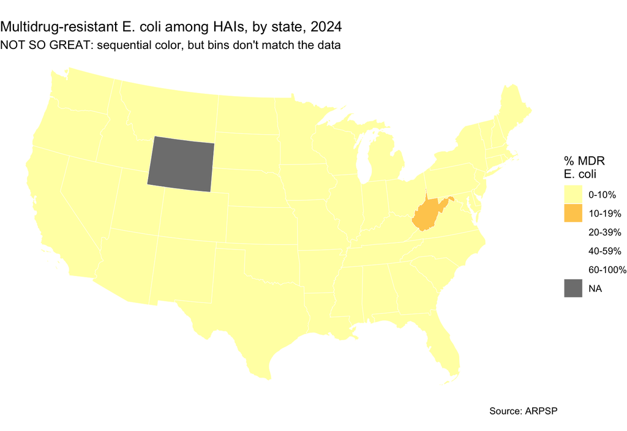

```r
# MAP 2 -- NOT SO GREAT: right idea (sequential yellow-to-red), wrong bins.
# These are naive round-number "percent" buckets (0-19, 20-39, ...) instead
# of bins built from the data's actual range. Real values only go up to
# ~25%, so almost every state falls into the first bucket and the map goes
# nearly flat -- you lose almost all the variation you're trying to show.
map_data_meh <- map_data %>%
  mutate(resist_bin = cut(percent_resistant,
                           breaks = c(0, 20, 40, 60, 80, 100),
                           labels = c("0-10%", "10-19%", "20-39%", "40-59%", "60-100%"),
                           include.lowest = TRUE))

ggplot(map_data_meh) +
  geom_sf(aes(fill = resist_bin), color = "white", linewidth = 0.15) +
  scale_fill_manual(values = c("0-10%" = "#FFFFB2", "10-19%" = "#FECC5C",
                                "20-39%" = "#FD8D3C", "40-59%" = "#F03B20",
                                "60-100%" = "#BD0026"),
                     name = "% MDR\nE. coli", drop = FALSE) +
  theme_void() +
  labs(title = "Multidrug-resistant E. coli among HAIs, by state, 2024",
       subtitle = "NOT SO GREAT: sequential color, but bins don't match the data",
       caption = "Source: ARPSP")
```

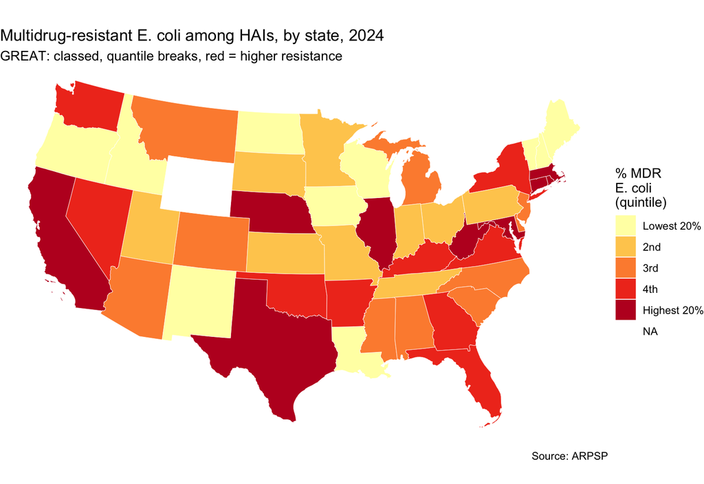

```r
# GREAT, classed version: quantile breaks so every bin has roughly the same
# number of states (no bin swallows the whole map, unlike Map 2's round
# numbers) + a red-toned sequential palette.
quantile_breaks <- quantile(map_data$percent_resistant, probs = seq(0, 1, 0.2), na.rm = TRUE)

map_data_great <- map_data %>%
  mutate(resist_bin = cut(percent_resistant, breaks = quantile_breaks,
                           include.lowest = TRUE,
                           labels = c("Lowest 20%", "2nd", "3rd", "4th", "Highest 20%")))

ggplot(map_data_great) +
  geom_sf(aes(fill = resist_bin), color = "white", linewidth = 0.15) +
  scale_fill_brewer(palette = "YlOrRd", name = "% MDR\nE. coli\n(quintile)") +
  theme_void() +
  labs(title = "Multidrug-resistant E. coli among HAIs, by state, 2024",
       subtitle = "GREAT: classed, quantile breaks, red = higher resistance",
       caption = "Source: ARPSP")
```

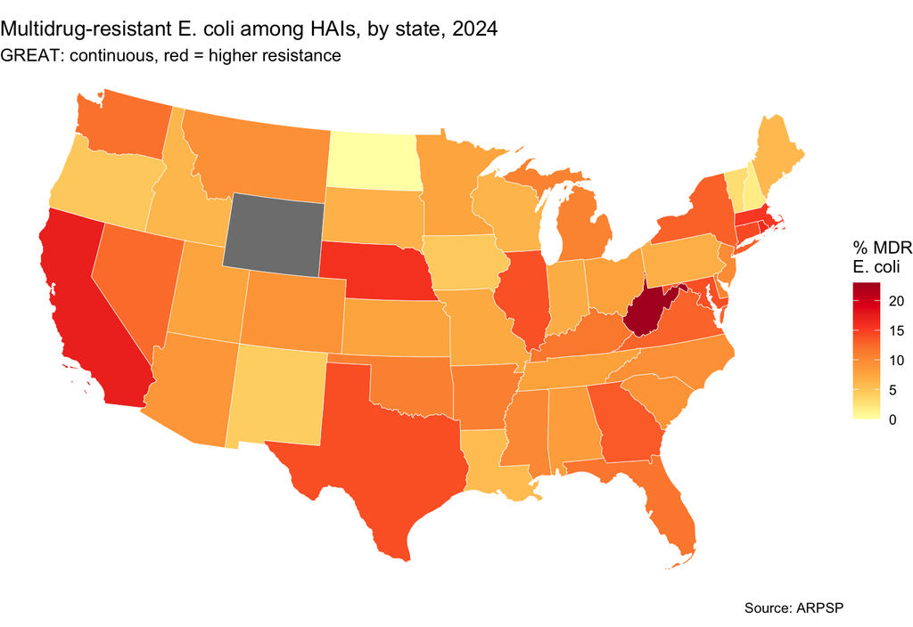

```r
ggplot(map_data) +
  geom_sf(aes(fill = percent_resistant), color = "white", linewidth = 0.15) +
  scale_fill_distiller(palette = "YlOrRd", direction = 1, name = "% MDR\nE. coli") +
  theme_void() +
  labs(title = "Multidrug-resistant E. coli among HAIs, by state, 2024",
       subtitle = "GREAT: continuous, red = higher resistance",
       caption = "Source: ARPSP")
```

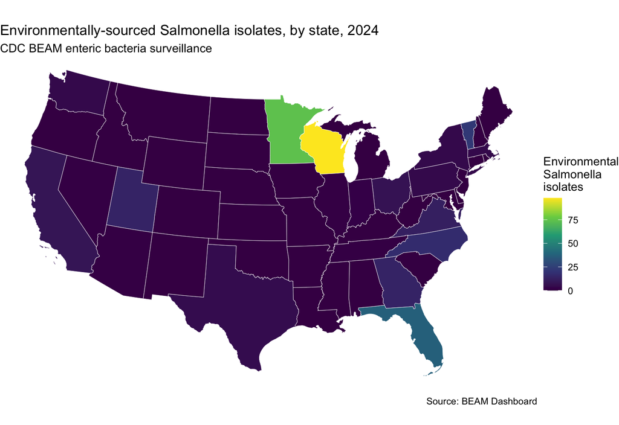

```r
ggplot(map_data) +
  geom_sf(aes(fill = env_isolates), color = "white", linewidth = 0.15) +
  scale_fill_viridis_c(name = "Environmental\nSalmonella\nisolates", option = "viridis") +
  theme_void() +
  labs(title = "Environmentally-sourced Salmonella isolates, by state, 2024",
       subtitle = "CDC BEAM enteric bacteria surveillance",
       caption = "Source: BEAM Dashboard")
```

[figure not shown]

```r
ggplot(map_data) +
  geom_sf(aes(fill = env_isolates), color = "white", linewidth = 0.15) +
  scale_fill_distiller(palette = "YlOrRd", direction = 1, name = "% MDR\nSalmonella") +
  theme_void() +
  labs(title = "Environmentally-sourced Salmonella isolates, by state, 2024",
       subtitle = "CDC BEAM enteric bacteria surveillance",
       caption = "Source: BEAM Dashboard")
```

**Discussion prompts:**

1. `scale_fill_viridis_c()` uses a *continuous* color gradient. What would change if you binned this into 4-5 categories instead (`scale_fill_viridis_b()`)? What decision are you making implicitly when you choose bin breaks (equal interval vs. quantile vs. Jenks natural breaks)? This is not a cosmetic choice — bin choice can visually create or hide a “hot spot.”
2. Look at the second map. Does it look like a map of environmental *Salmonella* contamination, or a map of *where states happened to test environmental samples*?

## 6.1 A note on missing data before we go further

Run `summary(map_data$percent_resistant)` again and look for `NA's`. One state — Wyoming — has a missing value in the ARPSP source data (not a join error). Small states often have their rates **suppressed** in public surveillance data when the underlying case count is too small to report reliably without a risk of re-identifying a patient. This is a real and recurring feature of small-area public health data, not a data-cleaning mistake to hide.

```r
map_data %>% st_drop_geometry() %>% filter(is.na(percent_resistant)) %>% select(name)
```

```
##      name
## 1 Wyoming
```

```r
map_data <- map_data %>% filter(!is.na(percent_resistant))
nrow(map_data)   # 48 states remain
```

```
## [1] 48
```

**Discussion:** dropping is not the only option — you could instead impute Wyoming’s value (e.g., a regional mean), but imputation should be a deliberate, documented choice.

# 7 Part 5 — Expanding across years: small multiples of environmental surveillance

A single choropleth is a snapshot. Most of the interesting questions in environmental pharmacoepidemiology are about *change* — did something increase, decrease, or stay flat? The standard way to show that spatially is a **small-multiples panel**: the same map, repeated once per time period, laid out in a grid so the eye can compare them directly.

Let’s rebuild the BEAM environmental *Salmonella* extract, this time keeping every full year from 2018 through 2025 (we’ll drop 2026 — it’s only partially reported as of today, and a partial year next to eight full years would make the most recent panel look like a decline that isn’t real).

```r
beam_env_years <- beam %>%
  filter(source_type == "Environment", pathogen == "Salmonella",
         year >= 2018, year <= 2025,
         state %in% valid_state_codes) %>%
  group_by(state, year) %>%
  summarize(isolates = sum(number_of_isolates, na.rm = TRUE), .groups = "drop")
```

Every CONUS state should get one row for *every* year, even the years it reported nothing — an absent row and a reported zero mean different things once you’re building a panel, and only one of them is correct here.

```r
beam_panel <- expand_grid(
  stusps = states_conus$stusps,
  year   = 2018:2025
) %>%
  left_join(beam_env_years, by = c("stusps" = "state", "year")) %>%
  mutate(isolates = coalesce(isolates, 0))

nrow(beam_panel)   # 49 states x 8 years
```

```
## [1] 392
```

```r
panel_sf <- states_conus %>%
  select(stusps, name, geometry) %>%
  left_join(beam_panel, by = "stusps")
```

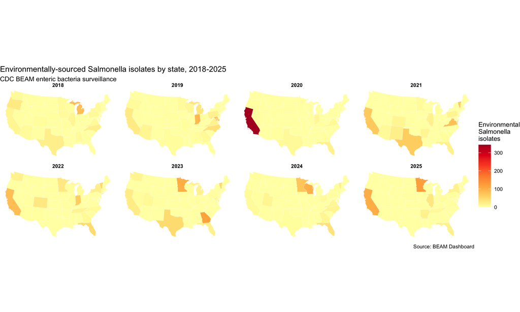

```r
ggplot(panel_sf) +
  geom_sf(aes(fill = isolates), color = "white", linewidth = 0.05) +
  facet_wrap(~ year, ncol = 4) +
  scale_fill_distiller(palette = "YlOrRd",  direction = 1, name = "Environmental\nSalmonella\nisolates",
                        limits = c(0, max(panel_sf$isolates))) +
  theme_void(base_size = 9) +
  theme(strip.text = element_text(face = "bold")) +
  labs(title = "Environmentally-sourced Salmonella isolates by state, 2018-2025",
       subtitle = "CDC BEAM enteric bacteria surveillance",
       caption = "Source: BEAM Dashboard")
```

**Why the `limits = c(0, max(panel_sf$isolates))`** Every panel here shares one color scale, built from the range of *all eight years combined*. If you instead mapped each year separately with its own default scale, a state with 5 isolates in a low year could look just as “dark” as a state with 50 isolates in a high year — same color, wildly different magnitude. A shared scale is what makes a small-multiples panel an honest comparison instead of eight unrelated pictures that happen to share an axis. This is arguably the single most common way choropleth series mislead a reader, and it’s a one-line fix.

**Discussion prompts:**

1. Which one or two states look like they’re driving most of the signal across the panel? Pull up their individual year-by-year isolate counts and check your visual read against the numbers.
2. Do any years look like a sharp jump or drop for many states at once (rather than one state)? A change that shows up broadly, in the same year, across unrelated states, is more likely a **reporting or methods change** than eight independent outbreaks.
3. Go back to your answer from Part 4, question 2. Now that you can see which states report *consistently* across all eight years versus which show up once or twice — does that change your read on whether this layer measures contamination, testing effort, or some mix of both?